# A short evening portrait of campus study spaces

## Overview

This visual data story examines observational logging data collected from campus study spaces. The dataset records where each observation was made, how many people were present, the overall noise level, and the timestamp of the response. For Project 4, I continued using the same Google Form from Project 2 and added a new set of observations during a short but focused evening observation session. This allows the visualisations to compare different study spaces while also showing how the observation session was distributed over time.

## Which spaces tend to be busiest?

The first visualisation compares the average number of people observed in each study space. This gives a clear overview of which locations tended to feel more crowded overall. It is useful because a simple count of observations does not show how busy a place was during each visit, while an average gives a more direct comparison of crowding.

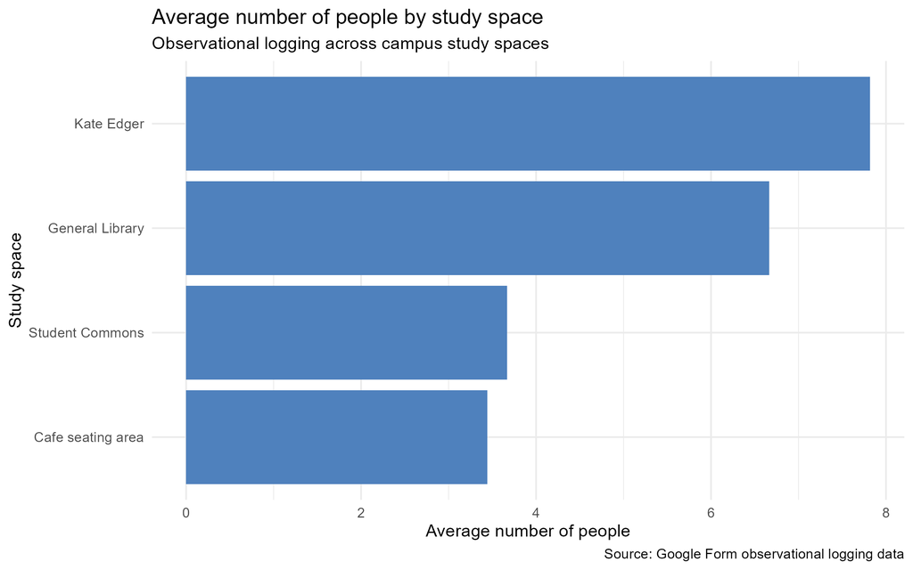

Horizontal bar chart showing average number of people by study space. Kate Edger and the General Library have the highest average counts, while Student Commons and the cafe seating area have lower averages.

This chart suggests that some study spaces were consistently busier than others. In particular, larger and more central study areas appear to attract more people, while smaller or more casual spaces had lower average crowding.

## How does noise differ across spaces?

The second visualisation compares the number of observations at different noise levels within each study space. This helps show whether some spaces were usually quieter, while others were more likely to be moderate or noisy.

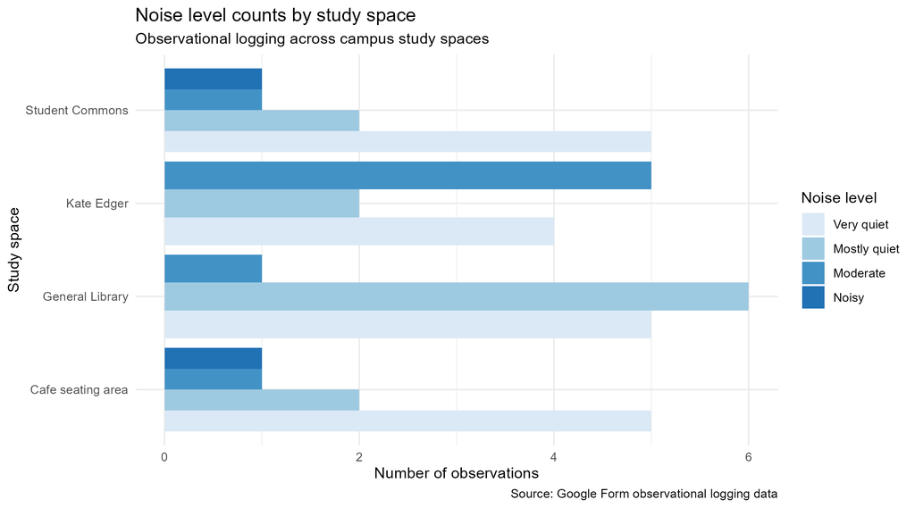

This chart adds context to the first one. A space can be busy without always being noisy, and a smaller space can still feel loud depending on how it is used. Looking at location and noise level together creates a more meaningful picture of how these study spaces function.

## A focused evening observation session

The final visualisation uses the timestamp variable. Instead of treating the data as a long-term trend, this chart focuses on the most recent observation session and groups responses into 5-minute blocks. This is appropriate because the newest observations were collected intensively within a short time period.

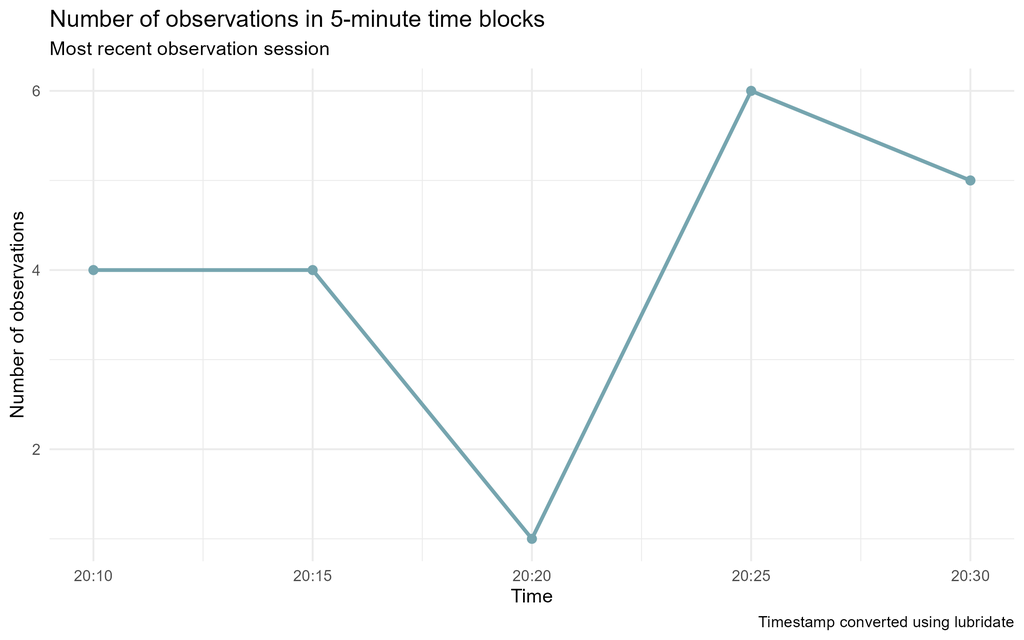

Line chart showing the number of observations in 5-minute blocks during the most recent evening observation session. Each point represents one short interval of time.

This figure shows the rhythm of the observation session itself. It helps explain how the data was gathered and gives a temporal structure to the visual story. Even though the session was short, the timestamp still adds useful information by showing that the data was collected progressively rather than entered all at once.

## What this story suggests

Taken together, these visualisations suggest that campus study spaces differ not only in how crowded they are, but also in how quiet or noisy they feel. The story also shows that even a short period of observational logging can produce useful comparisons when the data collection focus is clear and the visualisations are chosen carefully. By combining location, crowding, noise level, and time, the dataset becomes more than a list of responses and instead forms a small visual story about how study spaces were used during the observation period.